# Case Study 2 Project

Lauren Darr, Emmanuel Farrugia, John Heinen, Johnson Ekedum

23 April, 2017

# Introduction

This document will go through any data downloads, cleaning of data, visualization, and analysis conclusion.

Before getting started, load the doBy, ggplot2, lubridate, and dyplr packages into your R workspace. We will use functions from these packages through the project.

```r
#Following code checks if you have the packages doby, ggplot2, lubridate, and dyplr.  If you do not have, it will
#install the packages, if you do have, then it will not reinstall, it will just load the libraries.
if (!require("doBy")) {
  install.packages("doBy", repos="http://cran.rstudio.com/")
}
library(doBy)
if (!require("ggplot2")) {
  install.packages("ggplot2", repos="http://cran.rstudio.com/")
}
library(ggplot2)
if (!require("lubridate")) {
  install.packages("lubridate", repos="http://cran.rstudio.com/")
}
library(lubridate)
if (!require("dplyr")) {
  install.packages("dyplr", repos="http://cran.rstudio.com/")
}
library(dplyr)
```

## Question 2 Orange Trees

The Orange data is native to R, so we do not have to download from anywhere. We can move right in to answering the questions of interest for this problem. A little information on the data:

Tree: an ordered factor indicating the tree on which the measurement is made. The ordering is according to increasing maximum diameter. age: a numeric vector giving the age of the tree (days since 1968/12/31) circumference: a numeric vector of trunk circumferences (mm). This is probably “circumference at breast height”, a standard measurement in forestry.

First, we want to get the circumference mean and median for the trees.

```r
#Run the summaryBy function with mean and median as arguments in the list function to return the mean and median by Tree
summaryBy(circumference ~ Tree, data = Orange, FUN = list(mean, median))
```

```
##   Tree circumference.mean circumference.median
## 1    3           94.00000                  108
## 2    1           99.57143                  115
## 3    5          111.14286                  125
## 4    2          135.28571                  156
## 5    4          139.28571                  167
```

Next, we would like to plot the Age in days versus the Circumference of the trees, the plot will show different symbols and colors for each tree.

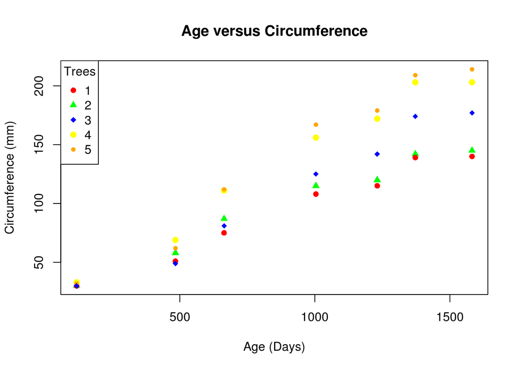

```r
##Plot of Age in Days versus Circumference (mm) of the trees in the data set, pch creates the different symbols
#used for each of the tree types plotted on the chart
plot(circumference ~ age,
           xlab = "Age (Days)",
           ylab = "Circumference (mm)",
           pch = c(16, 17, 18, 19, 20)[as.numeric(Tree)],  # different 'pch' types
           main = "Age versus Circumference",
           col = c("red", "green","blue", "yellow", "orange")[as.numeric(Tree)],
           data = Orange)

#Adds legend to the scatter plot to identify which symbol belongs to which tree.
legend("topleft", pch = c(16, 17, 18, 19, 20), col = c("red", "green","blue", "yellow", "orange"), legend = c("1","2","3","4","5"), title = "Trees")
```

Finally, we will look at comparitive boxplots of circumferences by tree, sorted in increasing order of maximum diameter.

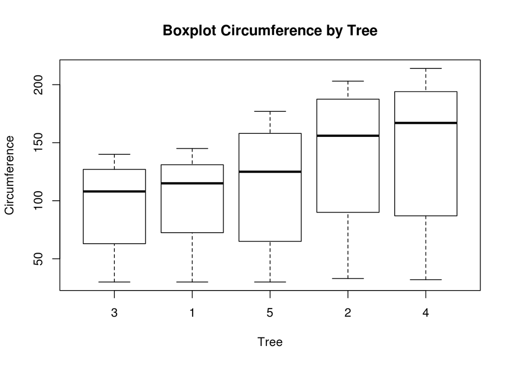

```r
#Comparitive Boxplots of Circumferences by Tree, sorted in increasing order of maximum diameter
boxplot(circumference~Tree,data=Orange, main="Boxplot Circumference by Tree", xlab="Tree", ylab="Circumference")
```

## Question 3 Country and City Temperatures

Next, we will take a look at a dataset of City temperatures since 1900. Like in the first graph, we will repor the top 20 cities with the largest range in minimum and maximum temperatures, but at the city level.

## Country Temperature Data

First, we must read in the data to begin our analysis.

```r
#Read in external data set "Temp.csv".
#Make sure to set your working directory accordingly for this project.
#This sets the data to a variable called Temp.data
#setwd("C:/Users/Lauren/Desktop/caseStudy2/Data")
#setwd("/home/jheinen001/Desktop/CaseStudy2_Final/data")
Temp.data <- read.csv("TEMP.csv", stringsAsFactors = FALSE )
```

Next, we must clean our data to make sure that it is ready for analysis. We will start by taking a look at the structure, view the data file, and look at the column headers.

```r
#first lets look at the structure of the Data
str(Temp.data)
```

```
## 'data.frame':    574223 obs. of  4 variables:
##  $ Date                           : chr  "1838-04-01" "1838-05-01" "1838-06-01" "1838-07-01" ...
##  $ Monthly.AverageTemp            : num  13 NA 23.9 26.9 24.9 ...
##  $ Monthly.AverageTemp.Uncertainty: num  2.59 NA 2.51 2.88 2.99 ...
##  $ Country                        : chr  "Afghanistan" "Afghanistan" "Afghanistan" "Afghanistan" ...
```

```r
#second view the data file
View(Temp.data)
#third look at the column headers
colnames(Temp.data)
```

```
## [1] "Date"                            "Monthly.AverageTemp"
## [3] "Monthly.AverageTemp.Uncertainty" "Country"
```

Now, we will check for NA’s in our dataset:

```r
#Let's also see if there are NA's within our dataset columns
sapply(Temp.data, function(x)  sum(is.na(x)) )
```

```
##                            Date             Monthly.AverageTemp
##                               0                           32578
## Monthly.AverageTemp.Uncertainty                         Country
##                           31839                               0
```

Finally, we will clean up our date values so that they all match and will make analysis by date possible.

```r
#Date cleanup: convert dates to "date" variables of matching format.
ymd<- ymd(Temp.data$Date)
mdy<- dmy(Temp.data$Date)
ymd[is.na(ymd)]<-mdy[is.na(ymd)]
Temp.data$Date<-ymd
Temp.data$year <- substr(Temp.data$Date,1,4)
Temp.data$year <- as.numeric(Temp.data$year)
```

Now we are ready to begin working with our data for analysis. We will have to calculate the range in maximum and minimum monthly average temperature for each country.

```r
#find the difference between the maximum and the minimum monthly average temperature for each country.
Temp.one <- Temp.data %>%
    select (Date,year, Country,Monthly.AverageTemp) %>%
    na.omit() %>%
    filter(year >= 1900) %>%
    group_by(Country)  %>%
  summarise(temp_diff = max(Monthly.AverageTemp) -
              min(Monthly.AverageTemp)) %>%
    arrange(desc(temp_diff))
Temp.one
```

```
## # A tibble: 241 × 2
##         Country temp_diff
##           <chr>     <dbl>
## 1    Kazakhstan    49.163
## 2      Mongolia    48.010
## 3        Russia    46.682
## 4        Canada    43.532
## 5    Uzbekistan    42.698
## 6  Turkmenistan    40.579
## 7       Belarus    39.338
## 8       Finland    39.068
## 9       Estonia    38.815
## 10      Ukraine    38.660
## # ... with 231 more rows
```

We are able to plot our first graph to answer the question of interest in Question 3.i.

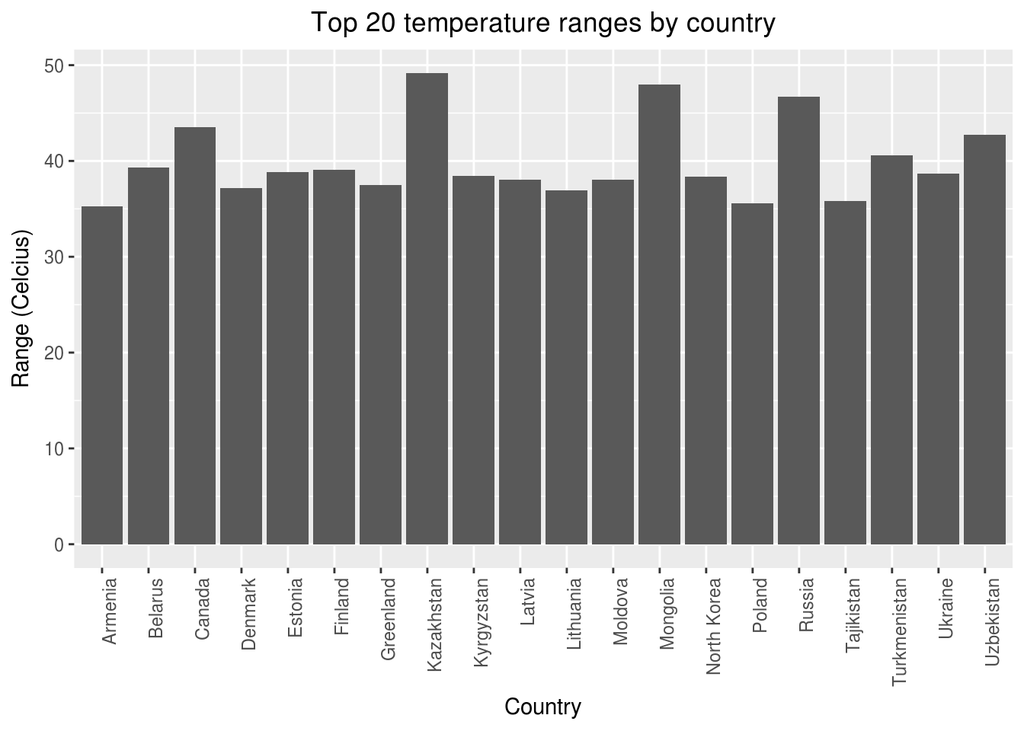

```r
#report/visualize top 20 countries with the maximum differences for the period since 1900.
ggplot(Temp.one[1:20,], aes(Country,temp_diff)) + geom_col() + theme(axis.text.x=element_text(angle=90, hjust=1)) + xlab("Country") + ylab ("Range (Celcius)") + ggtitle("Top 20 temperature ranges by country") + theme(plot.title=element_text(hjust=0.5))
```

For Question 3.ii we will now look at a subset of the data and focus on US temperatures. Our first task is to create a new column in the data and convert the degrees in celcius to farenheit.

```r
#Create a new column to display the monthly average land temperatures in Fahrenheit.
Temp.two <- Temp.data %>% na.omit %>%
  select (year, Monthly.AverageTemp,Country) %>%
  filter ( Country=='United States', year >= 1900 ) %>%
  mutate(Temp_Fahrenheit= Monthly.AverageTemp  * 9/5 + 32 ) %>%
  select (year, Temp_Fahrenheit)%>%
  group_by(year) %>%
  summarise(Avg_land_temp=mean(Temp_Fahrenheit) )
#Display new column
Temp.two
```

```
## # A tibble: 114 × 2
##     year Avg_land_temp
##    <dbl>         <dbl>
## 1   1900      48.23885
## 2   1901      47.29085
## 3   1902      47.21720
## 4   1903      46.35905
## 5   1904      46.76120
## 6   1905      47.12420
## 7   1906      47.40815
## 8   1907      47.10920
## 9   1908      47.76005
## 10  1909      46.79930
## # ... with 104 more rows
```

We will now plot the average land temperature by year for 3.ii.b:

[figure not shown]

```r
ggplot(Temp.two,aes(year,Avg_land_temp)) + geom_line() + xlab("Year") + ylab ("Avg. Yearly Temp (Fahrenheit)") + ggtitle("Average Yearly Temperatures in the U.S. 1990-2013") + theme(plot.title=element_text(hjust=0.5))
```

Finally for question 3.ii.c, we will calculate the one year difference of average land temperature by year and provide the maximum difference with the corresponding two years.

```r
#Calculate the one year difference of average land temperature by year and
#provide the maximum difference (value) with corresponding two years.
difference_in_temp <- diff(Temp.two$Avg_land_temp)
temp3 <- cbind(Temp.two[1:113,],difference_in_temp)
#Display maximum difference in temp
which.max(temp3$difference_in_temp)
```

```
## [1] 21
```

```r
#Display temp difference for next two years
temp3[c(21,22),]
```

```
##    year Avg_land_temp difference_in_temp
## 21 1920       46.7321             2.5401
## 22 1921       49.2722            -1.4895
```

Display temperature difference for the following two years of 2.54 and -1.49 respectively.

We will now move to question 3.iii, in which we will work with a new data set of city temperatures. We will first have to bring in the new data set to our workspace.

```r
#Read in data set.
City.data <- read.csv("CityTemp.csv", stringsAsFactors = FALSE )
```

Again, we will have to clean up the data in order to make sure it is ready to use. We will first look at the first few rows of the data, and then the structure of the data.

```r
# Check first rows of dataset
head(City.data)
```

```
##         Date Monthly.AverageTemp Monthly.AverageTemp.Uncertainty
## 1 1850-01-01              15.986                           1.537
## 2 1850-02-01              18.345                           1.527
## 3 1850-03-01              18.632                           2.162
## 4 1850-04-01              18.154                           1.693
## 5 1850-05-01              17.480                           1.237
## 6 1850-06-01              17.183                           1.252
##          City  Country Latitude Longitude
## 1 Addis Abeba Ethiopia    8.84N    38.11E
## 2 Addis Abeba Ethiopia    8.84N    38.11E
## 3 Addis Abeba Ethiopia    8.84N    38.11E
## 4 Addis Abeba Ethiopia    8.84N    38.11E
## 5 Addis Abeba Ethiopia    8.84N    38.11E
## 6 Addis Abeba Ethiopia    8.84N    38.11E
```

```r
# Check structure of dataset
str(City.data)
```

```
## 'data.frame':    237200 obs. of  7 variables:
##  $ Date                           : chr  "1850-01-01" "1850-02-01" "1850-03-01" "1850-04-01" ...
##  $ Monthly.AverageTemp            : num  16 18.3 18.6 18.2 17.5 ...
##  $ Monthly.AverageTemp.Uncertainty: num  1.54 1.53 2.16 1.69 1.24 ...
##  $ City                           : chr  "Addis Abeba" "Addis Abeba" "Addis Abeba" "Addis Abeba" ...
##  $ Country                        : chr  "Ethiopia" "Ethiopia" "Ethiopia" "Ethiopia" ...
##  $ Latitude                       : chr  "8.84N" "8.84N" "8.84N" "8.84N" ...
##  $ Longitude                      : chr  "38.11E" "38.11E" "38.11E" "38.11E" ...
```

We need to clean up the date field in this data set.

```r
#Date Cleaning
ymd<- ymd(City.data$Date)
mdy<- dmy(City.data$Date)
ymd[is.na(ymd)]<-mdy[is.na(ymd)]
City.data$Date<-ymd

City.data$year<- substr(City.data$Date,1,4)
City.data$year <- as.numeric(City.data$year)
```

Now we can calculate the difference between the maximum and minimum temperatures for each major city and then display a graph of the top 20 cities with maximum differences for the period since 1900.

```r
#Find the difference between the maximum and the minimum temperatures
#for each major city
City.one<- City.data %>%
  select (year,City,Monthly.AverageTemp) %>%
  na.omit() %>%
  filter(year >= 1900) %>%
  group_by(City)  %>%
  summarise(temp_diff = max(Monthly.AverageTemp) -
              min(Monthly.AverageTemp)) %>%
  arrange(desc(temp_diff))
City.one
```

```
## # A tibble: 99 × 2
##                City temp_diff
##               <chr>     <dbl>
## 1            Harbin    53.281
## 2         Changchun    49.844
## 3            Moscow    43.956
## 4          Shenyang    43.045
## 5          Montreal    41.422
## 6              Kiev    40.784
## 7  Saint Petersburg    40.510
## 8           Toronto    38.683
## 9           Taiyuan    37.834
## 10           Peking    36.953
## # ... with 89 more rows
```

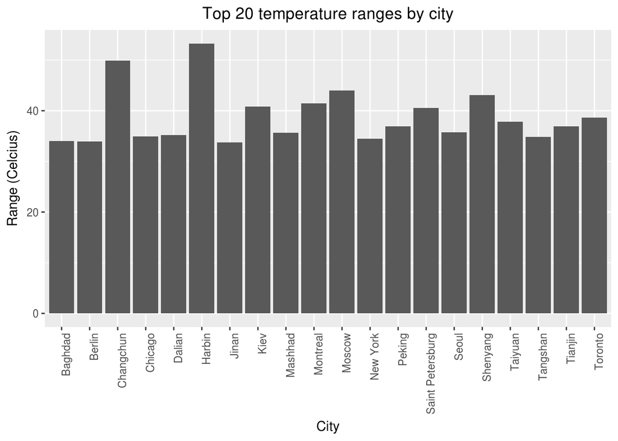

```r
#visualize top 20 cities with maximum differences for the period since 1900.
ggplot(City.one[1:20,], aes(City,temp_diff)) + geom_col() + theme(axis.text.x=element_text(angle=90, hjust=1)) + xlab("City") + ylab ("Range (Celcius)") + ggtitle("Top 20 temperature ranges by city") + theme(plot.title=element_text(hjust=0.5))
```

## Conclusion

For the questions of interest in this project, we were able to utilize the skills in R that we have acquired over the semester. We were able to pull in data, clean it, conduct analysis, and then provide various visuals. In this particular project we worked with Orange Tree data and saw a linear correlation between age of a tree and circumference. We also worked with Country and City temperature data and were able to analyze that data for a large period of time.